# Logistic Regression

2023-02-13

```r
knitr::opts_chunk$set(echo = TRUE)
library(tidyverse)
library(janitor)
library(tidymodels)
```

# The Data

```r
patients <- read.csv("breast-cancer.csv") %>%
  clean_names() %>%
  mutate(class = as.factor(class))
```

To get a sense for how logistic regression works, consider the following plot:

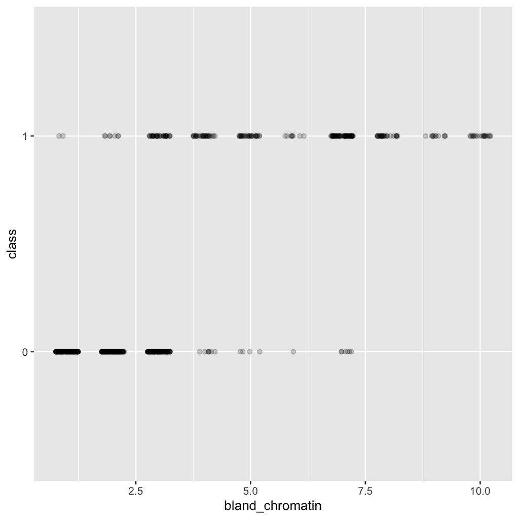

```r
ggplot(patients, aes(x=bland_chromatin, y=class)) +
  geom_point(position = position_jitter(w = 0.25, h = 0), alpha=.2)
```

```r
patients_split <- initial_split(patients, prop=.8)

patients_train <- training(patients_split)
patients_test <- testing(patients_split)

patients_folds <- vfold_cv(patients_train, v=10)
```

# Logistic Regression

Let’s create a logistic regression model specification.

```r
logistic_model <- logistic_reg() %>%
  set_engine("glm") %>% # the default, stands for "generalized linear models"
  set_mode("classification") # also the default
```

What kinds of preprocessing should we use? Check out the appendix in TMWR.

```r
logistic_recipe <- recipe(class ~ ., data=patients_train) %>%
  #update_role(id, new_role="id") %>%
  step_normalize(all_numeric_predictors())

logistic_wf <- workflow() %>%
  add_model(logistic_model) %>%
  add_recipe(logistic_recipe)
```

Cross-validate the model to estimate performance:

```r
logistic_wf %>%
  fit_resamples(resamples=patients_folds) %>%
  collect_metrics()
```

```
## # A tibble: 2 × 6
##   .metric  .estimator  mean     n std_err .config
##   <chr>    <chr>      <dbl> <int>   <dbl> <chr>
## 1 accuracy binary     0.974    10 0.00780 Preprocessor1_Model1
## 2 roc_auc  binary     0.996    10 0.00156 Preprocessor1_Model1
```

```r
logistic_results <- logistic_wf %>%
  fit(data=patients_train) %>%
  augment(new_data=patients_test)

my_metrics <- metric_set(accuracy, sens, spec)
accuracy(logistic_results, truth=class, estimate=.pred_class)
```

```
## # A tibble: 1 × 3
##   .metric  .estimator .estimate
##   <chr>    <chr>          <dbl>
## 1 accuracy binary         0.956
```

```r
# logistic_results %>%
#   mutate(class = as.numeric(class)-1) %>%
#   ggplot(aes(x=bland_chromatin)) +
#   geom_point(aes(y=as.numeric(class)), alpha=.5) +
#   geom_point(aes(y=.pred_1), color="blue")
```

# Your turn

We will continue to work on the titanic activity (KNN). Once you finish the specified steps, complete the following:

1. Build, cross-validate, and train a logistic regression model. Is there any difference in performance between the two methods?
2. Use the `tune()` and `tune_grid()` functions to choose the value of $k$ that maximizes the accuracy of your KNN model.

# Penalized Regression

We can implement a penalized regression model (linear or logistic) using the `glmnet` package. Make sure you install this package before you run!

```r
penalized_model <- logistic_reg(penalty=tune()) %>%
  set_engine("glmnet") %>% # the default, stands for "generalized linear models"
  set_mode("classification") # also the default

penalized_wf <- workflow() %>%
  add_model(penalized_model) %>%
  add_recipe(logistic_recipe)
```

Cross-validate the model to tune parameters:

```r
penalized_wf %>%
  tune_grid(
    resamples=patients_folds,
    grid=10,
    metrics = metric_set(accuracy)
  ) %>%
  show_best(n=5)
```

```
## # A tibble: 5 × 7
##    penalty .metric  .estimator  mean     n std_err .config
##      <dbl> <chr>    <chr>      <dbl> <int>   <dbl> <chr>
## 1 3.41e-10 accuracy binary     0.974    10 0.00780 Preprocessor1_Model01
## 2 1.34e- 9 accuracy binary     0.974    10 0.00780 Preprocessor1_Model02
## 3 1.43e- 8 accuracy binary     0.974    10 0.00780 Preprocessor1_Model03
## 4 6.96e- 7 accuracy binary     0.974    10 0.00780 Preprocessor1_Model04
## 5 4.61e- 6 accuracy binary     0.974    10 0.00780 Preprocessor1_Model05
```

Smaller values of the penalty mean the penalty has less influence. I would interpret the results above to mean that penalization is actually hurting performance! This is likely because I gave you a good set of predictors. In this case, I would probably stick to a parameter of 0.

```r
penalized_results <- penalized_wf %>%
  finalize_workflow(
    parameters = tibble(penalty=0)
  ) %>%
  fit(data=patients_train) %>%
  augment(new_data=patients_test)

my_metrics(penalized_results, truth=class, estimate=.pred_class)
```

```
## # A tibble: 3 × 3
##   .metric  .estimator .estimate
##   <chr>    <chr>          <dbl>
## 1 accuracy binary         0.956
## 2 sens     binary         0.958
## 3 spec     binary         0.951
```